# Arbeidsfysiologisk metode og Statistikk

Statistisk inferens: Quiz

## Spørsmål 1: Tolke et resultat

En studie undersøker hvordan muskelmasse forandres med trening hos eldre menn og kvinner som trener et styrkeprogram. Resultatene fra studien viser at muskelmasse øker med 6.31%, (95% KI: [2.81, 9.81], p = 0.0005, t = 3.57, df = 114).

Hva stemmer?

> Gjennomsnittlig forskjell i utvalget er 6.31%, populasjonsgjennomsnittet kan finnes innad konfidensintervallet [2.81, 9.81]. P-verdien indikerer at det observerte resultatet er svært usannsynlig hvis nullhypotesen er sann.

## Spørsmål 2: Tolke en p-verdi

Du beregner en p-verdi på 0.051. Når du planla din studie ønsket du å begrense risikoen for type 1 feil til 5%.

Hva stemmer?

> Resultatet er ikke statistisk signifikant, vi har ikke bevis for å forkaste nullhypotesen.

## Spørsmål 3: Hva er nullhypotesen?

Thrane (2020, kap. 4) har gjennomført et eksperiment hvor en gruppe studenter tilfeldig blir gitt informasjon, et anker, som gir en hint om andel afrikanske land som er medlem i FN. I eksperimentet ønsker vi å si noe om et anker har betydelse for hvordan man besvarer etterfølgende spørsmål. Vi sammenligner gruppene som blir gitt anker 65% og 10%.

Hva er nullhypotesen i denne sammenhengen?

> Nullhypotesen sier at det ikke er en gjennomsnittlig forskjell mellom gruppene i besvarelse.

## Spørsmål 4: “Statistic”?

Thrane (2020, kap. 4) har gjennomført et eksperiment hvor en gruppe studenter tilfeldig blir gitt informasjon, et anker, som gir en hint om andel afrikanske land som er medlem i FN. I eksperimentet ønsker vi å si noe om et anker har betydelse for hvordan man besvarer etterfølgende spørsmål. Vi sammenligner gruppene som blir gitt anker 65% og 10%.

Åpne datasettet FN_eks_1_2_3.csv i jamovi. Bruk en uavhengig students t-test med anker som gruppevariable og FN_prosent som avhengig variabel. Angi “statistic” med to desimaler:

| Anker | Gjennomsnitt | SD | n |
| --- | --- | --- | --- |
| 10 | 24.8 | 25.0 | 73 |
| 65 | 46.0 | 23.3 | 65 |

## Spørsmål 4: “Statistic”?

Hva er “statistic”?

$$t = \frac{Estimat}{SE}$$

| Koeffisient | Estimat | SE | t | p |
| --- | --- | --- | --- | --- |
| Skjæringspunkt | 24.82 | 2.83 | 8.76 | 0.000000 |
| Anker 65% | 21.19 | 4.13 | 5.13 | 0.000001 |

## Spørsmål 5: Statistic fra regresjonsmodell

[figure not shown]

## Spørsmål 6: Konfidensintervall

Hva er den nedre grensen for et 95% konfidensintervallet som du kan beregne ved hjelp av Students t-test på FN-dataene fra Thrane (2020)? Angi med to desimaler.

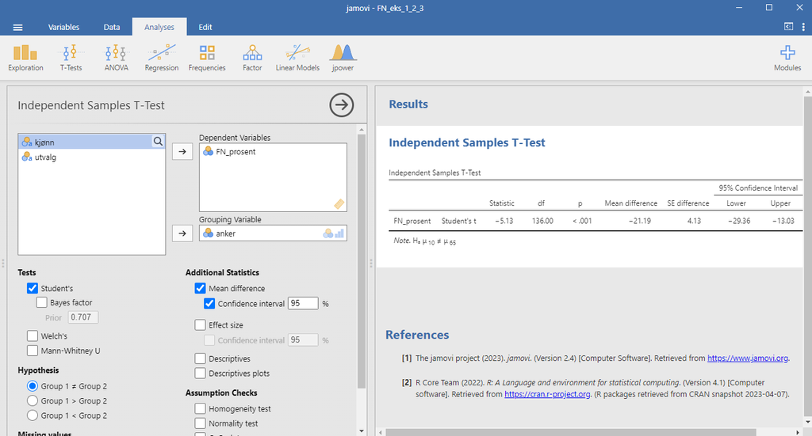

## Spørsmål 7: Konfidensintervall

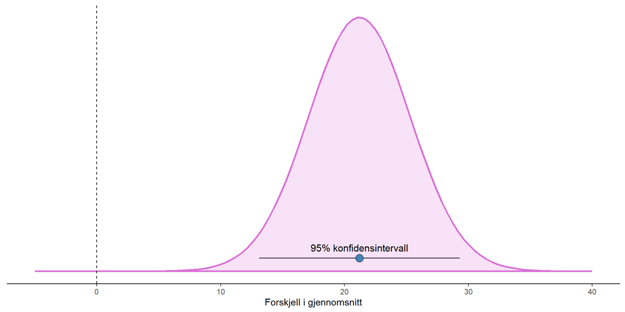

## Spørsmål 7: Konfidensintervall

> Vi finner ikke nullhypotesen (0) i det observerte 95% intervallet, hvis vi setter grensen for statistisk signifikans til 5% (alfa = 0.05) tilsvarer dette et signifikant resultat.

## Spørsmål 8: Planlegg en studie

Du ønsker å undersøke effekten av to forskjellige treningsprogrammer på maksimalt oksygenopptak (VO2maks) hos eliteutøvere. En differens etter en intervensjon på 200 ml/min er relevant for å si noe om prestasjonspotesiale til deltakerne. Du forventer en spredning i forandring i VO2maks på 250 ml/min, noe som gir en effektsstørrelse på 0.8. Du ønsker en statistisk styrke på 95% og feilrate for type 1 feil til 5%. Hvor mange deltakere trenger du i studiet ditt (per gruppe)?

## Spørsmål 8: Planlegg en studie

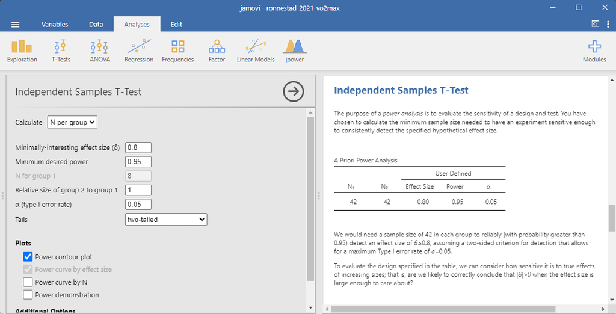

## Spørsmål 9: Gjennomfør en analyse

Vi har nå samlet inn dataene! Åpne filen `ronnestad-2021-vo2max.xlsx` i jamovi. Gjennomfør en t-test (Independent samples students t-test) mellom gruppene (LI og SI) på en ny variabel som beregnes som forskjell mellom pre og post (post - pre). Angi p-verdien med tre desimaler.

> p = 0.019

## Spørsmål 10: Typisk utvalgsstørrelse

Utvalgsstørrelsen i ronnestad-2021-vo2max.xlsx er liten. Hvilken statistisk styrke kan du forvente for lignende studier (effektstørrelse: 0.8, risiko for type 1 feil: 5%, antall deltakere per gruppe: 8)?

> 0.32!